# Assignment 5: Handle Missing Values

*How to do it?*:

- Open the Rmarkdown file of this assignment (link) in Rstudio.
- Right under each **question**, insert a code chunk (you can use the hotkey `Ctrl + Alt + I` to add a code chunk) and code the solution for the question.
- `Knit` the rmarkdown file (hotkey: `Ctrl + Alt + K`) to export an html.
- Publish the html file to your Githiub Page.

*Submission*: Submit the link on Github of the assignment to Canvas.

**The data:**

This assignment works with the Adult Census Data that can be downloaded at [this link.](https://bryantstats.github.io/math421/data/adult_census_missing.csv)

**Questions**

```r
library(tidyverse)
df <- read_csv("https://bryantstats.github.io/math421/data/adult_census_missing.csv")
```

2. Using function `aggr` the VIM package to plot the number of NAs for each column.

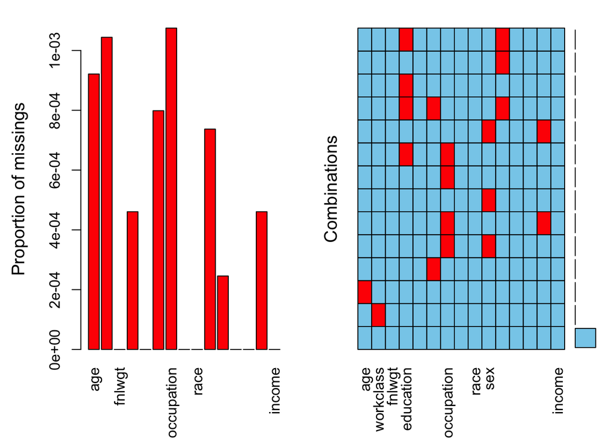

```r
library(VIM)
aggr(df)
```

3. Find other forms of missing values. Hint: You can use the `table` function to check if there are suspicious categories (Unknown, for example) in a variable. What all other forms of missing values shown in the data.

```r
table(df$workclass)
```

```
##
##                ?      Federal-gov        Local-gov     Never-worked
##             1835              957             2086                7
##        Not Known          Private     Self-emp-inc Self-emp-not-inc
##               12            22664             1110             2537
##        State-gov          Unknown      Without-pay
##             1293               12               14
```

According to the df “workclass” table, there are other forms of missing values under the categories, “Not Known, Unknown, and ?”

4. Replace all the forms of missing values found to NA

```r
df <- df %>% na_if('Unknown') %>% na_if('Not Known') %>% na_if('?')
```

```r
table(df$workclass)
```

```
##
##      Federal-gov        Local-gov     Never-worked          Private
##              957             2086                7            22664
##     Self-emp-inc Self-emp-not-inc        State-gov      Without-pay
##             1110             2537             1293               14
```

6. Approach 1 to handle NAs: remove all rows that have any NAs. Save the dataset after removing as a different data. The original data is unchanged (still have NAs). How many rows left after removing?

```r
df2 = drop_na(df)
```

Rows left: 29,865

7. Approach 2 to handle NAs: Fill all the NAs with the previous or next value. (Hint: Using `fill` function). Save the dataset after filling as a different data. The original data is unchanged (still have NAs).

```r
df3 = df %>% fill(workclass, .direction = 'updown')
```

8. Approach 3 to handle NAs: For numeric variable, replace the NAs by the median. For categorical variables, replace the NAs to the majority.

```r
df$worklass <- replace_na(df$workclass, 'Public')
```